# ch05_03_01_model_validation(1)

### 1.1.1 이진 분류의 평가지표

#### 1.1.2 임계값과 평가지표

#### 1.1.3 평가지표 - ROC 커브, AUC

#### 1.1.4 다중 분류의 평가지표

### 학습 내용

- 이진 분류의 평가 지표에 대해 알아본다.
- 불균형 데이터 셋일때의 정확도에 대해 알아본다.
- 정밀도, 민감도, 특이도, FPRate, F-score에 대해 알아본다.
- 함수를 활용하여 각각의 모델별 정밀도, 민감도, F-score를 확인해 본다.

```python
from IPython.display import display, Image
import warnings
warnings.filterwarnings(action='ignore')
```

```python
import pandas as pd
import numpy as np
from sklearn.model_selection import train_test_split
import matplotlib.pyplot as plt
import seaborn as sns
```

### 01 데이터 셋 준비

### 데이터 셋

- 손글씨 데이터
- data : 1797장, 64개의 pixel 데이터
  - images : 1797, 8, 8
- target : 0~9까지의 손글씨 값
- pixel : 화소(텔레비전·컴퓨터 화면의 화상을 구성하는 최소 단위)
  - 화면 이미지들은 더 이상 쪼개지지 않는 사각형의 작은 점들이 모여 이뤄진다. 이때 이미지를 구성하는 최소 단위를 픽셀이라고 한다.

[figure not shown]

```python
## 머신러닝 작업 flow
display(Image(filename='img/model_validation_pixel01.png'))
```

```
(1797, 64)
dict_keys(['data', 'target', 'frame', 'feature_names', 'target_names', 'images', 'DESCR']) [0 1 2 ... 8 9 8]
[0 1 2 3 4 5 6 7 8 9]
```

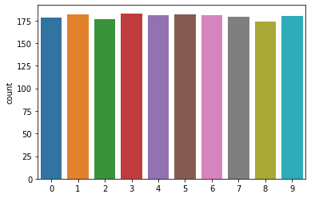

```python
from sklearn.datasets import load_digits

digits = load_digits()
print(digits.data.shape)
print(digits.keys(), digits.target)
print(np.unique( digits.target ) )
sns.countplot(digits.target)
```

### Target 값을 이진값으로 만들기

### 데이터 셋의 Target(타깃)이 9:1의 비율로 나누기

- 9이면 True
- 9가 아니면 False

```python
X = digits.data             # 입력
y = digits.target == 9      # 출력

X_train, X_test, y_train, y_test = train_test_split(X, y, random_state=0)
```

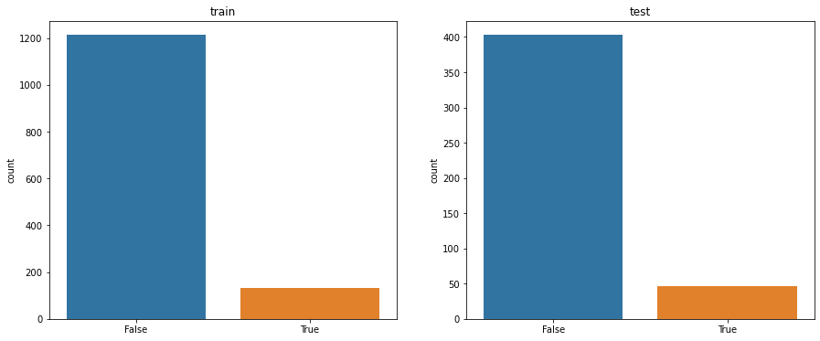

```python
plt.figure(figsize=(15,6))
plt.subplot(1, 2, 1)
# y_train의 값 확인
sns.countplot(y_train)
plt.title("train")

plt.subplot(1, 2, 2)
# y_test의 값 확인
sns.countplot(y_test)
plt.title("test")
```

### 02 다양한 모델의 평가

- 정확도(accuracy) 확인

### 02-01 기본 모델 DummyClassifier

- 간단한 규칙을 사용하여 예측을 수행한다.
- 실제 프로젝트에서 사용하지 않으며, **간단한 베이스라인 모델**로서 사용된다.
- DummyClassifier(strategy='most_frequent') : 학습용 세트에서 가장 많이 있는 Label(라벨)을 예측한다.
  - most_frequent : 가장 많이 있는 Label(라벨)을 예측
  - stratified : 클래스 분포를 존중하여 예측을 생성
  - uniform : 무작위로 균일하게 예측을 생성 ,
  - 기타 : prior, constant
- 아래 모델은 가장 많은 레이블을 가진 False만 예측하게 된다.

```python
from sklearn.dummy import DummyClassifier
dummy_model = DummyClassifier(strategy='most_frequent').fit(X_train, y_train)
pred_most_frequent = dummy_model.predict(X_test)
print("예측된 레이블의 고유값: {}".format(np.unique(pred_most_frequent)))
print("테스트 점수: {:.2f}".format(dummy_model.score(X_test, y_test)))
```

```
예측된 레이블의 고유값: [False]
테스트 점수: 0.90
```

### 02-02 DummyClassifier를 이용한 예측

- 매개변수 없을 때의 기본 동작
  - stratified : 클래스 분포를 고려하여 예측
- 클래스의 9:1 분포를 가만하여 예측

```python
dummy = DummyClassifier(strategy='stratified').fit(X_train, y_train)
pred_dummy = dummy.predict(X_test)
print("예측된 레이블의 고유값: {}".format(np.unique(pred_dummy)))
print("dummy 점수: {:.2f}".format(dummy.score(X_test, y_test)))
```

```
예측된 레이블의 고유값: [False  True]
dummy 점수: 0.82
```

### 02-03 실제 모델 - DecisionTreeClassifier

```python
from sklearn.tree import DecisionTreeClassifier
tree = DecisionTreeClassifier(max_depth=2).fit(X_train, y_train)
pred_tree = tree.predict(X_test)
print("테스트 점수: {:.2f}".format(tree.score(X_test, y_test)))
```

```
테스트 점수: 0.92
```

- 실제 분류기와 기본 모델 dummy 분류기와 성능차이가 거의 없다.

### 02-04 LogisticRegression(로지스틱 회귀) 모델

```python
from sklearn.linear_model import LogisticRegression

logreg = LogisticRegression(C=0.1).fit(X_train, y_train)
pred_logreg = logreg.predict(X_test)
print("logreg 점수: {:.2f}".format(logreg.score(X_test, y_test)))
```

```
logreg 점수: 0.98
```

### 하나만 예측하는 기본 모델도 90% 이상의 정확도를 갖는다.

- 정확도는 때로는 평가지표로 사용하기에 부족한 부분이 있다.

### 정확도 대신에 사용할 지표가 무엇이 있을까?

### 03 오차행렬(confusion matrix)을 이용하기

```python
import mglearn
```

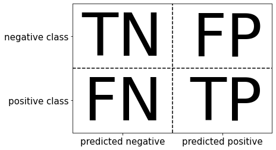

```python
mglearn.plots.plot_binary_confusion_matrix()
```

### confusion_matrix 를 이용한 오차(혼동) 행렬 구하기

```python
from sklearn.metrics import confusion_matrix

confusion = confusion_matrix(y_test, pred_logreg)
print("오차 행렬:\n{}".format(confusion))
```

```
오차 행렬:
[[402   1]
 [  6  41]]
```

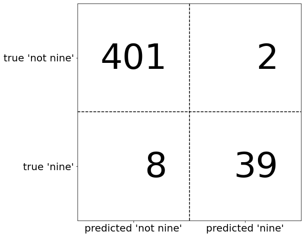

```python
mglearn.plots.plot_confusion_matrix_illustration()
```

### 3-1 각각의 예측값에 대한 오차행렬을 확인해보기

- 행은 정답 클래스에 해당하고, 열은 예측 클래스에 해당

```python
print("빈도 기반 더미 모델:")
print(confusion_matrix(y_test, pred_most_frequent))

print("\n무작위 더미 모델:")
print(confusion_matrix(y_test, pred_dummy))

print("\n결정 트리:")
print(confusion_matrix(y_test, pred_tree))

print("\n로지스틱 회귀")
print(confusion_matrix(y_test, pred_logreg))
```

```
빈도 기반 더미 모델:
[[403   0]
 [ 47   0]]

무작위 더미 모델:
[[362  41]
 [ 44   3]]

결정 트리:
[[390  13]
 [ 24  23]]

로지스틱 회귀
[[402   1]
 [  6  41]]
```

### 3-2 분류의 다양한 평가지표를 살펴보기

- 정확도(accuracy) : 정확하게 예측/전체 예측수
- 정밀도(precision) : 양성으로 예측한 것중(TP+FP), 진짜 양성(TP)
- 민감도(sensitivity), 재현율(recall) : 전체 양성 샘플(TP + FN)중에서 얼마나 많은 샘플이 양성 클래스로 분류(TP)
- 특이도
- Fprate
- F-score
- AUC

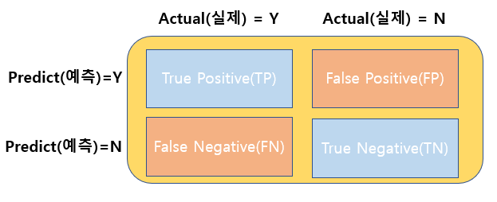

```python
## 머신러닝 작업 flow
display(Image(filename='img/model_validation01.png'))
```

### 분류의 평가지표를 살펴보자.

### 정확도(accuracy) : 정확하게 예측/전체 예측수

\begin{equation} \text{accuracy} = \frac{\text{TP} + \text{TN}}{\text{TP} + \text{FP} + \text{FN} + \text{TN}} \end{equation}

### 정밀도(precision) : 예측을 양성(Positive)으로 한것 전체(TP+FP)중에 잘 예측한 것(TP)

\begin{equation} \text{정밀도(precision)} = \frac{\text{잘 예측(TP)}}{ \text{예측을 양성으로 한 것 전체(TP+FP) } } \end{equation}

- 언제 사용하는가? : **거짓 양성(FP)의 수를 줄일 때** 사용
  - 임상 실험을 통해 신약의 치료 효과를 예측하는 모델
  - 임상 실험은 가격이 매우 비싸, 제약회사는 한번의 임상실험으로 신약의 효과를 검증하기를 원함. 모델이 거짓 양성(FP)을 많이 만들지 않는 것이 중요. 높은 정밀도가 필요. 이때 정밀도를 지표로 확인

### 민감도(sensitivity), 재현율(recall, TPRate), 진짜 양성 비율(TPR)

- 전체 **실제 양성 데이터(TP + FN)**중에 얼마나 많은 샘플을 양성으로 잘 분류했나?(TP)
- TP/(TP + FN)

\begin{equation} \text{민감도(recall, 재현율)} = \frac{\text{잘 예측(TP)}}{ \text{전체 양성 샘플 전체(TP+FN) } } \end{equation}

### 특이도

- 전체 **실제 데이터의 음성 데이터(FP + TN)**중에 제대로 예측한 샘플(음성 예측)?(TN)
- TN/(FP + TN)

\begin{equation} \text{특이도} = \frac{\text{잘 예측(TN)}}{ \text{실제 값이 음성인것 전체(FP + TN) } } \end{equation}

### FPRate

- 전체 **실제 데이터의 음성 데이터(FP + TN)**중에 예측을 실패(양성 예측), 잘 분류하지 못한 것?(FP)
- FP/(FP + TN)

\begin{equation} \text{FPRate} = \frac{\text{틀린 예측(FP)}}{ \text{실제 값이 음성인것 전체(FP + TN) } } \end{equation}

### 다양한 분류 측정 방법

- https://en.wikipedia.org/wiki/Sensitivity_and_specificity
- 이진 분류에서는 정밀도와 재현율을 가장 많이 사용.
  - 분야마다 다른 지표를 사용할 수 있다.

### F-score

- 오차 행렬의 결과를 요약하는 여러 방법 중 가장 일반적인 것은 정밀도, 재현율이다.
- 정밀도와 재현율은 중요한 측정 방법이지만, 둘중의 하나의 방법으로 전체 그림을 보기가 어렵다.
- 정밀도와 민감도(recall,재현율)을 하나만 가지고 측정이 안된다. 정밀도(precision)와 재현율(recall)의 조화 평균인 f-점수 또는 f-측정은 이 둘을 하나로 요약을 해 줍니다.

\begin{equation} \text{F} = 2 * \frac{\text{정밀도*재현율}}{ \text{정밀도 + 재현율 } } \end{equation}

\begin{equation} \text{위의 공식을 우리는}f_1 점수라고 한다. \end{equation}

- 정밀도와 재현율을 함께 고려하므로 불균형한 이진 분류 데이터셋에서의 **정확도보다 더 나은 지표**가 될 수 있다.

### 3-3 f1-score를 확인해보기

### 각각의 모델 예측값을 f1-score로 예측

```python
from sklearn.metrics import f1_score

# 빈도기반 모델 f1-score
print("무작위 더미 모델의 f1 score: {:.2f}".format(f1_score(y_test, pred_most_frequent)))

# Dummy분류 f1-score
print("무작위 더미 모델의 f1 score: {:.2f}".format(f1_score(y_test, pred_dummy)))

# 의사결정트리
print("트리 모델의 f1 score: {:.2f}".format(f1_score(y_test, pred_tree)))

# 로지스틱
print("로지스틱 회귀 모델의 f1 score: {:.2f}".format(f1_score(y_test, pred_logreg)))
```

```
무작위 더미 모델의 f1 score: 0.00
무작위 더미 모델의 f1 score: 0.07
트리 모델의 f1 score: 0.55
로지스틱 회귀 모델의 f1 score: 0.92
```

### f1-score를 요약해서 보여주기

- classification_report() : 정밀도, 재현율, f1-score을 모두 한번에 계산
- support는 단순히 샘플의 수
- macro avg : 단순히 클래스별 점수의 평균 계산
- weighted avg : 클래스의 샘플수로 가중 평균

```python
from sklearn.metrics import classification_report
print(classification_report(y_test, pred_most_frequent,
                           target_names=["not 9", "is 9"]))
```

```
              precision    recall  f1-score   support

       not 9       0.90      1.00      0.94       403
        is 9       0.00      0.00      0.00        47

    accuracy                           0.90       450
   macro avg       0.45      0.50      0.47       450
weighted avg       0.80      0.90      0.85       450
```

### dummyClassifier 모델

```python
from sklearn.metrics import classification_report
print(classification_report(y_test, pred_dummy,
                            target_names=["not 9", "is 9"]))
```

```
              precision    recall  f1-score   support

       not 9       0.89      0.90      0.89       403
        is 9       0.07      0.06      0.07        47

    accuracy                           0.81       450
   macro avg       0.48      0.48      0.48       450
weighted avg       0.81      0.81      0.81       450
```

### 의사결정트리

```python
from sklearn.metrics import classification_report
print(classification_report(y_test,
                            pred_tree,
                            target_names=["not 9", "is 9"]))
```

```
              precision    recall  f1-score   support

       not 9       0.94      0.97      0.95       403
        is 9       0.64      0.49      0.55        47

    accuracy                           0.92       450
   macro avg       0.79      0.73      0.75       450
weighted avg       0.91      0.92      0.91       450
```

### 로지스틱 회귀

```python
from sklearn.metrics import classification_report
print(classification_report(y_test,
                            pred_logreg,
                            target_names=["not 9", "is 9"]))
```

```
              precision    recall  f1-score   support

       not 9       0.99      1.00      0.99       403
        is 9       0.98      0.87      0.92        47

    accuracy                           0.98       450
   macro avg       0.98      0.93      0.96       450
weighted avg       0.98      0.98      0.98       450
```

교육용으로 작성된 것으로 배포 및 복제시에 사전 허가가 필요합니다.  
Copyright 2021 LIM Co. all rights reserved.